# Size structure

# Tic-Tac-Toe Plot

(Bluegill & Largemouth Bass)

The **tic-tac-toe plot** is a great way to use the PSD data. It visualizes whether the proportion of quality fish for a prey and predator species is the way we want it.

Essentially, you, as a manager choose some target PSD values for your two species, in this case Bluegill and Largemouth Bass.

The target PSD values depends on whether we want a pond with an abundance of panfish, one with balanced populations, or one with larger bass.

We can then use the `ticTacToe()` function from the `FSA` package to visualize where our PSD values fall in relation to those targets.

We can plot the tic-tac-toe section for the “Panfish” scenario as follows:

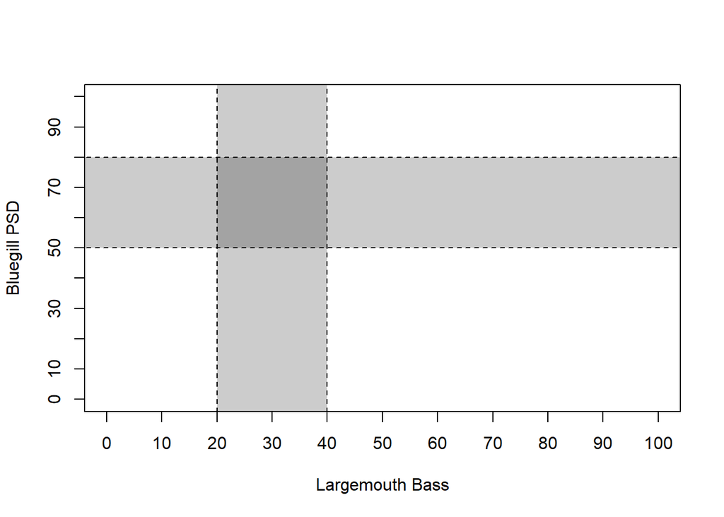

```r
tictactoe(predlab="Largemouth Bass", preylab="Bluegill PSD", predobj=c(20,40),preyobj=c(50,80))
```

We can add our observed PSD values like this:

First, we need the values we observed:

```r
psdCalc(~tl_mm, data = bluegill, species = "Bluegill", what = "all")
```

```
        Estimate 95% LCI 95% UCI
PSD-Q         38      32      44
PSD-P         12       8      15
PSD S-Q       62      56      68
PSD Q-P       27      21      32
PSD P-M       12       8      15
```

And we can see that the PSD for bluegill is 38, with a CI spanning from 32 to 44.

```r
psdCalc(~tl_mm, data = bass, species = "Largemouth Bass", what = "all")
```

```
        Estimate 95% LCI 95% UCI
PSD-Q         42      35      50
PSD-P         15      10      21
PSD-M          2       0       4
PSD S-Q       58      50      65
PSD Q-P       27      20      34
PSD P-M       14       8      19
PSD M-T        2       0       4
```

And we can see that the PSD for Largemouth Bass is 42, with a CI spanning from 35 to 50.

[figure not shown]

```r
library(plotrix)
tictactoe(predlab="Largemouth Bass", preylab="Bluegill PSD", predobj=c(20,40),preyobj=c(50,80))

plotCI(38, 42, li=32, ui=44, err="x",pch=16,add=TRUE)
plotCI(38, 42, li=35, ui=50, err="y",pch=16,add=TRUE)
```

We are simply adding points and CI’s on top of the plot

**Question 7 (5 pts)**

If you are a manager that wants to create a pond dominated by panfish, do you think the current PSD values for Bluegill and Largemouth Bass are good? Why or why not? What do you need to do to meet the target PSD values for that scenario?

**Question 8 (5 pts)**

Plot a tic-tac-toe plot for the “Balanced” scenario. Add your observed PSD values for Bluegill and Largemouth Bass. Do you think the current PSD values are good for a balanced pond? Why or why not? What do you need to do to meet the target PSD values for that scenario?